# Lab 1.5: Annotation Resources

July 2023

# Contents

Authors: Martin Morgan, Sonali Arora, Lori Shepherd  
Back: Intro labs

**Objective**: Learn about *Bioconductor* resources for gene and genome annotation.

**Lessons learned**:

- Use `org.*` packages for mapping between gene symbols.
- Use `TxDb.*` and `ensembldb` (`EnsDb.*`) packages for working with gene models.
- Use `AnnotationHub` to easily obtain select consortium-level resources
- Access `biomaRt` and other internet-based resources for highly flexible annotation.
- Use `VariantAnnotation` and `VariantFiltering` for annotating SNPs.

**Note**: It may be helpful to wait or look at lecture material for annotations planned for Wednesday.

# 1 Gene annotation

## 1.1 Data packages

Organism-level (‘org’) packages contain mappings between a central identifier (e.g., Entrez gene ids) and other identifiers (e.g. GenBank or Uniprot accession number, RefSeq id, etc.). The name of an org package is always of the form `org.<Sp>.<id>.db` (e.g. org.Sc.sgd.db) where `<Sp>` is a 2-letter abbreviation of the organism (e.g. `Sc` for *Saccharomyces cerevisiae*) and `<id>` is an abbreviation (in lower-case) describing the type of central identifier (e.g. `sgd` for gene identifiers assigned by the *Saccharomyces* Genome Database, or `eg` for Entrez gene ids). The “How to use the ‘.db’ annotation packages” vignette in the AnnotationDbi package (org packages are only one type of “.db” annotation packages) is a key reference. The ‘.db’ and most other Bioconductor annotation packages are updated every 6 months.

Annotation packages usually contain an object named after the package itself. These objects are collectively called `AnnotationDb` objects, with more specific classes named `OrgDb`, `ChipDb` or `TranscriptDb` objects. Methods that can be applied to these objects include `cols()`, `keys()`, `keytypes()` and `select()`. Common operations for retrieving annotations are summarized in the table.

| Category | Function | Description |
| --- | --- | --- |
| Discover | `columns()` | List the kinds of columns that can be returned |
|  | `keytypes()` | List columns that can be used as keys |
|  | `keys()` | List values that can be expected for a given keytype |
|  | `select()` | Retrieve annotations matching `keys`, `keytype` and `columns` |
| Manipulate | `setdiff()`, `union()`, `intersect()` | Operations on sets |
|  | `duplicated()`, `unique()` | Mark or remove duplicates |
|  | `%in%`, `match()` | Find matches |
|  | `any()`, `all()` | Are any `TRUE`? Are all? |
|  | `merge()` | Combine two different based on shared keys |
| `GRanges*` | `transcripts()`, `exons()`, `cds()` | Features (transcripts, exons, coding sequence) as `GRanges`. |
|  | `transcriptsBy()` , `exonsBy()` | Features group by gene, transcript, etc., as `GRangesList`. |
|  | `cdsBy()` |  |

## 1.2 Internet resources

A short summary of select Bioconductor packages enabling web-based queries is in following Table.

| Package | Description |
| --- | --- |
| AnnotationHub | Ensembl, Encode, dbSNP, UCSC data objects |
| [biomaRt](http://biomart.org) | Ensembl and other annotations |
| [PSICQUIC](https://code.google.com/p/psicquic) | Protein interactions |
| [uniprot.ws](http://uniprot.org) | Protein annotations |
| [KEGGREST](http://www.genome.jp/kegg) | KEGG pathways |
| [SRAdb](http://www.ncbi.nlm.nih.gov/sra) | Sequencing experiments. |
| [rtracklayer](http://genome.ucsc.edu) | genome tracks. |
| [GEOquery](http://www.ncbi.nlm.nih.gov/geo/) | Array and other data |
| [ArrayExpress](http://www.ebi.ac.uk/arrayexpress/) | Array and other data |

## 1.3 Exercises

**Exercise 1**: This exercise illustrates basic use of the `select’ interface to annotation packages.

1. Install and attach the org.Hs.eg.db annotation package; it contains ‘symbol mapping’ information for *Homo sapiens*, based on NCBI ‘Entrez’ identifiers.

   ```r
   library(org.Hs.eg.db)
   ```

2. Take a quick look at a summary of data in this package

   ```r
   org.Hs.eg.db
   ```

   ```
   ## OrgDb object:
   ## | DBSCHEMAVERSION: 2.1
   ## | Db type: OrgDb
   ## | Supporting package: AnnotationDbi
   ## | DBSCHEMA: HUMAN_DB
   ## | ORGANISM: Homo sapiens
   ## | SPECIES: Human
   ## | EGSOURCEDATE: 2023-Mar05
   ## | EGSOURCENAME: Entrez Gene
   ## | EGSOURCEURL: ftp://ftp.ncbi.nlm.nih.gov/gene/DATA
   ## | CENTRALID: EG
   ## | TAXID: 9606
   ## | GOSOURCENAME: Gene Ontology
   ## | GOSOURCEURL: http://current.geneontology.org/ontology/go-basic.obo
   ## | GOSOURCEDATE: 2023-01-01
   ## | GOEGSOURCEDATE: 2023-Mar05
   ## | GOEGSOURCENAME: Entrez Gene
   ## | GOEGSOURCEURL: ftp://ftp.ncbi.nlm.nih.gov/gene/DATA
   ## | KEGGSOURCENAME: KEGG GENOME
   ## | KEGGSOURCEURL: ftp://ftp.genome.jp/pub/kegg/genomes
   ## | KEGGSOURCEDATE: 2011-Mar15
   ## | GPSOURCENAME: UCSC Genome Bioinformatics (Homo sapiens)
   ## | GPSOURCEURL:
   ## | GPSOURCEDATE: 2023-Feb8
   ## | ENSOURCEDATE: 2023-Feb10
   ## | ENSOURCENAME: Ensembl
   ## | ENSOURCEURL: ftp://ftp.ensembl.org/pub/current_fasta
   ## | UPSOURCENAME: Uniprot
   ## | UPSOURCEURL: http://www.UniProt.org/
   ## | UPSOURCEDATE: Wed Mar 15 15:58:07 2023
   ```

   ```
   ##
   ## Please see: help('select') for usage information
   ```

3. The idea is that there are `keytypes()` that can be mapped to different `columns()`; `keys()` can be used to see available keys. Explore the package to see what sorts of information is available, e.g.,

   ```r
   keytypes(org.Hs.eg.db)
   ```

   ```
   ##  [1] "ACCNUM"       "ALIAS"        "ENSEMBL"      "ENSEMBLPROT"  "ENSEMBLTRANS"
   ##  [6] "ENTREZID"     "ENZYME"       "EVIDENCE"     "EVIDENCEALL"  "GENENAME"
   ## [11] "GENETYPE"     "GO"           "GOALL"        "IPI"          "MAP"
   ## [16] "OMIM"         "ONTOLOGY"     "ONTOLOGYALL"  "PATH"         "PFAM"
   ## [21] "PMID"         "PROSITE"      "REFSEQ"       "SYMBOL"       "UCSCKG"
   ## [26] "UNIPROT"
   ```

   ```r
   columns(org.Hs.eg.db)
   ```

   ```
   ##  [1] "ACCNUM"       "ALIAS"        "ENSEMBL"      "ENSEMBLPROT"  "ENSEMBLTRANS"
   ##  [6] "ENTREZID"     "ENZYME"       "EVIDENCE"     "EVIDENCEALL"  "GENENAME"
   ## [11] "GENETYPE"     "GO"           "GOALL"        "IPI"          "MAP"
   ## [16] "OMIM"         "ONTOLOGY"     "ONTOLOGYALL"  "PATH"         "PFAM"
   ## [21] "PMID"         "PROSITE"      "REFSEQ"       "SYMBOL"       "UCSCKG"
   ## [26] "UNIPROT"
   ```

   ```r
   head(keys(org.Hs.eg.db, "SYMBOL"))
   ```

   ```
   ## [1] "A1BG"  "A2M"   "A2MP1" "NAT1"  "NAT2"  "NATP"
   ```

4. There are two basic ways of extracting data from an `org.*` package – `mapIds()` to create a 1:1 mapping between key and a single column, and `select()` (it’s often necessary to specify this function directly, to avoid a conflict with dplyr, as `AnnotationDbi::select()`). Explore these functions, e.g.,

   ```r
   set.seed(123)
   egid <- sample(keys(org.Hs.eg.db), 6)
   mapIds(org.Hs.eg.db, egid, "SYMBOL", "ENTREZID")
   ```

   ```
   ##      127891097      127829507      127408100      127829992      105374253
   ## "LOC127891097" "LOC127829507" "LOC127408100" "LOC127829992" "LOC105374253"
   ##      124900425
   ## "LOC124900425"
   ```

   ```r
   AnnotationDbi::select(
       org.Hs.eg.db, egid, c("SYMBOL", "ENSEMBL", "GENENAME"), "ENTREZID"
   )
   ```

   ```
   ##    ENTREZID       SYMBOL         ENSEMBL
   ## 1 127891097 LOC127891097            <NA>
   ## 2 127829507 LOC127829507            <NA>
   ## 3 127408100 LOC127408100            <NA>
   ## 4 127829992 LOC127829992            <NA>
   ## 5 105374253 LOC105374253            <NA>
   ## 6 124900425 LOC124900425 ENSG00000201898
   ##                                               GENENAME
   ## 1 H3K4me1 hESC enhancer GRCh37_chr19:29402081-29402580
   ## 2 H3K4me1 hESC enhancer GRCh37_chr15:50201373-50201873
   ## 3      H3K4me1 hESC enhancer GRCh37_chr7:947339-948037
   ## 4 H3K4me1 hESC enhancer GRCh37_chr15:69958631-69959245
   ## 5                         uncharacterized LOC105374253
   ## 6                          small nucleolar RNA SNORA72
   ```

   ```r
   egid <- "3812"
   mapIds(org.Hs.eg.db, egid, "ENSEMBL", "ENTREZID")
   ```

   ```
   ##              3812
   ## "ENSG00000240403"
   ```

   ```r
   mapIds(
       org.Hs.eg.db, egid, "ENSEMBL", "ENTREZID",
       multiVals = "CharacterList"
   )
   ```

   ```
   ## CharacterList of length 1
   ## [["3812"]] ENSG00000240403 ENSG00000273735 ... ENSG00000284063 ENSG00000283975
   ```

   ```r
   AnnotationDbi::select(
       org.Hs.eg.db, egid, c("SYMBOL", "ENSEMBL"),
       multiVals = "CharacterList"
   )
   ```

   ```
   ##    ENTREZID  SYMBOL         ENSEMBL
   ## 1      3812 KIR3DL2 ENSG00000240403
   ## 2      3812 KIR3DL2 ENSG00000273735
   ## 3      3812 KIR3DL2 ENSG00000275511
   ## 4      3812 KIR3DL2 ENSG00000276424
   ## 5      3812 KIR3DL2 ENSG00000274722
   ## 6      3812 KIR3DL2 ENSG00000278850
   ## 7      3812 KIR3DL2 ENSG00000278710
   ## 8      3812 KIR3DL2 ENSG00000276004
   ## 9      3812 KIR3DL2 ENSG00000278474
   ## 10     3812 KIR3DL2 ENSG00000278726
   ## 11     3812 KIR3DL2 ENSG00000278442
   ## 12     3812 KIR3DL2 ENSG00000278758
   ## 13     3812 KIR3DL2 ENSG00000275262
   ## 14     3812 KIR3DL2 ENSG00000275629
   ```

   [output cut: 29 more lines]

6. It seems like it might often be useful to use the tidyverse on return values from `mapIds()` and `select()`; explore this usage

   ```r
   library(tidyverse)
   egid <- keys(org.Hs.eg.db)    # all ENTREZIDs
   mapIds(org.Hs.eg.db, egid, "SYMBOL", "ENTREZID") |>
      as_tibble() |>
      rownames_to_column("ENTREZID")
   ```

   ```
   ## # A tibble: 142,352 × 2
   ##    ENTREZID value
   ##    <chr>    <chr>
   ##  1 1        A1BG
   ##  2 2        A2M
   ##  3 3        A2MP1
   ##  4 4        NAT1
   ##  5 5        NAT2
   ##  6 6        NATP
   ##  7 7        SERPINA3
   ##  8 8        AADAC
   ##  9 9        AAMP
   ## 10 10       AANAT
   ## # ℹ 142,342 more rows
   ```

   ```r
   AnnotationDbi::select(
       org.Hs.eg.db, egid, c("SYMBOL", "GO", "GENENAME"), "ENTREZID"
   ) |>
       as_tibble()
   ```

   ```
   ## # A tibble: 459,026 × 6
   ##    ENTREZID SYMBOL GO         EVIDENCE ONTOLOGY GENENAME
   ##    <chr>    <chr>  <chr>      <chr>    <chr>    <chr>
   ##  1 1        A1BG   GO:0003674 ND       MF       alpha-1-B glycoprotein
   ##  2 1        A1BG   GO:0005576 HDA      CC       alpha-1-B glycoprotein
   ##  3 1        A1BG   GO:0005576 IDA      CC       alpha-1-B glycoprotein
   ##  4 1        A1BG   GO:0005576 TAS      CC       alpha-1-B glycoprotein
   ##  5 1        A1BG   GO:0005615 HDA      CC       alpha-1-B glycoprotein
   ##  6 1        A1BG   GO:0005886 IBA      CC       alpha-1-B glycoprotein
   ##  7 1        A1BG   GO:0008150 ND       BP       alpha-1-B glycoprotein
   ##  8 1        A1BG   GO:0031093 TAS      CC       alpha-1-B glycoprotein
   ##  9 1        A1BG   GO:0034774 TAS      CC       alpha-1-B glycoprotein
   ## 10 1        A1BG   GO:0062023 HDA      CC       alpha-1-B glycoprotein
   ## # ℹ 459,016 more rows
   ```

**Concept Check**:

After completing this previous section you should be able to answer the following:

1. What gene symbol corresponds to Entrez Gene ID 1000?
2. What is the Ensembl Gene ID for PPARG?
3. What is the UniProt ID for GAPDH?

**Exercise 2**: biomaRt.

Internet access required for this exercise

1. Explore the Biomart web site https://www.ensembl.org/biomart for retrieving all kinds of genomic annotations.

   Start by choosing a database (e.g., ‘Ensembl Genes 92’), dataset (e.g., ‘Human genes (GRCh38.p12)’), filter (e.g., ‘GENE’ / ‘Input external reference’ / ‘Gene stable id’ and enter ‘ENSG00000000003’), attributes (default is ok), then press ‘Results’ to map from Ensembl identifier to transcript identifier.
2. Install (if necessary) and load the biomaRt package. Use `listMarts()` to see availble databases, `useMart()` to select the mart you’re interested in.

   ```r
   library(biomaRt)
   head(listMarts())
   ```

   ```
   ##                biomart                version
   ## 1 ENSEMBL_MART_ENSEMBL      Ensembl Genes 109
   ## 2   ENSEMBL_MART_MOUSE      Mouse strains 109
   ## 3     ENSEMBL_MART_SNP  Ensembl Variation 109
   ## 4 ENSEMBL_MART_FUNCGEN Ensembl Regulation 109
   ```

   ```r
   mart <- useMart("ENSEMBL_MART_ENSEMBL")
   ```

3. Use `listDatasets()` and `useDataset()` to select the *Homo sapiens* gene dataset.

   ```r
   head(listDatasets(mart))
   ```

   ```
   ##                        dataset                           description
   ## 1 abrachyrhynchus_gene_ensembl Pink-footed goose genes (ASM259213v1)
   ## 2     acalliptera_gene_ensembl      Eastern happy genes (fAstCal1.2)
   ## 3   acarolinensis_gene_ensembl       Green anole genes (AnoCar2.0v2)
   ## 4    acchrysaetos_gene_ensembl       Golden eagle genes (bAquChr1.2)
   ## 5    acitrinellus_gene_ensembl        Midas cichlid genes (Midas_v5)
   ## 6    amelanoleuca_gene_ensembl       Giant panda genes (ASM200744v2)
   ##       version
   ## 1 ASM259213v1
   ## 2  fAstCal1.2
   ## 3 AnoCar2.0v2
   ## 4  bAquChr1.2
   ## 5    Midas_v5
   ## 6 ASM200744v2
   ```

   ```r
   dataset <- useDataset("hsapiens_gene_ensembl", mart)
   ```

4. Use `listFilters()` to see available filters. The filter is the type of data that you are querying with. Choose one.

   ```r
   head(listFilters(dataset))
   ```

   ```
   ##              name              description
   ## 1 chromosome_name Chromosome/scaffold name
   ## 2           start                    Start
   ## 3             end                      End
   ## 4      band_start               Band Start
   ## 5        band_end                 Band End
   ## 6    marker_start             Marker Start
   ```

   ```r
   filters <- "ensembl_gene_id"                    # see `listFilters()`
   ```

5. Use `listAttrbutes()` to see available attributes. Attributes represent the information you’d like to retrieve. Choose some!

   ```r
   head(listAttributes(dataset))
   ```

   ```
   ##                            name                  description         page
   ## 1               ensembl_gene_id               Gene stable ID feature_page
   ## 2       ensembl_gene_id_version       Gene stable ID version feature_page
   ## 3         ensembl_transcript_id         Transcript stable ID feature_page
   ## 4 ensembl_transcript_id_version Transcript stable ID version feature_page
   ## 5            ensembl_peptide_id            Protein stable ID feature_page
   ## 6    ensembl_peptide_id_version    Protein stable ID version feature_page
   ```

   ```r
   attrs <- c("ensembl_gene_id", "hgnc_symbol")    # see `listAttributes()`
   ```

6. Create a character vector of Ensembl gene ids, compose and execute the query, transforming the result to a tibble.

   ```r
   ids <- c(
       "ENSG00000000003", "ENSG00000000005", "ENSG00000000419",
       "ENSG00000000457", "ENSG00000000460", "ENSG00000000938"
   )
   tbl <-
       getBM(attrs, filters, ids, dataset) |>
       as_tibble()
   tbl
   ```

   ```
   ## # A tibble: 6 × 2
   ##   ensembl_gene_id hgnc_symbol
   ##   <chr>           <chr>
   ## 1 ENSG00000000003 TSPAN6
   ## 2 ENSG00000000005 TNMD
   ## 3 ENSG00000000419 DPM1
   ## 4 ENSG00000000457 SCYL3
   ## 5 ENSG00000000460 C1orf112
   ## 6 ENSG00000000938 FGR
   ```

**Exercise 3**: KEGGREST

Internet access required for this exercise

1. Explore the KEGG web site https://www.genome.jp/kegg/ KEGG is a database of information on pathways.
2. Load the KEGGREST package and discover available databases

   ```r
   library(KEGGREST)
   KEGGREST::listDatabases()
   ```

   ```
   ##  [1] "pathway"  "brite"    "module"   "ko"       "genome"   "vg"
   ##  [7] "ag"       "compound" "glycan"   "reaction" "rclass"   "enzyme"
   ## [13] "disease"  "drug"     "dgroup"   "environ"  "genes"    "ligand"
   ## [19] "kegg"
   ```

3. Use `keggList()` to query the pathway database for human pathways; present the result as a tibble

   ```r
   hsa_pathways <-
       keggList("pathway", "hsa") |>
       enframe(name = "pathway", value = "description")
   hsa_pathways
   ```

   ```
   ## # A tibble: 354 × 2
   ##    pathway  description
   ##    <chr>    <chr>
   ##  1 hsa01100 Metabolic pathways - Homo sapiens (human)
   ##  2 hsa01200 Carbon metabolism - Homo sapiens (human)
   ##  3 hsa01210 2-Oxocarboxylic acid metabolism - Homo sapiens (human)
   ##  4 hsa01212 Fatty acid metabolism - Homo sapiens (human)
   ##  5 hsa01230 Biosynthesis of amino acids - Homo sapiens (human)
   ##  6 hsa01232 Nucleotide metabolism - Homo sapiens (human)
   ##  7 hsa01250 Biosynthesis of nucleotide sugars - Homo sapiens (human)
   ##  8 hsa01240 Biosynthesis of cofactors - Homo sapiens (human)
   ##  9 hsa00010 Glycolysis / Gluconeogenesis - Homo sapiens (human)
   ## 10 hsa00020 Citrate cycle (TCA cycle) - Homo sapiens (human)
   ## # ℹ 344 more rows
   ```

4. Use `keggLink()` to recover the genes in each pathway.

   ```r
   hsa_path_eg  <-
       keggLink("pathway", "hsa") |>
       enframe(name = "egid", value = "pathway") |>
       mutate(egid = sub("hsa:", "", egid))
   hsa_path_eg
   ```

   ```
   ## # A tibble: 36,249 × 2
   ##    egid   pathway
   ##    <chr>  <chr>
   ##  1 10327  path:hsa00010
   ##  2 124    path:hsa00010
   ##  3 125    path:hsa00010
   ##  4 126    path:hsa00010
   ##  5 127    path:hsa00010
   ##  6 128    path:hsa00010
   ##  7 130    path:hsa00010
   ##  8 130589 path:hsa00010
   ##  9 131    path:hsa00010
   ## 10 160287 path:hsa00010
   ## # ℹ 36,239 more rows
   ```

   ```r
   hsa_path_eg |>
       group_by(pathway) |>
       summarize(genes = list(egid))
   ```

   ```
   ## # A tibble: 354 × 2
   ##    pathway       genes
   ##    <chr>         <list>
   ##  1 path:hsa00010 <chr [67]>
   ##  2 path:hsa00020 <chr [30]>
   ##  3 path:hsa00030 <chr [30]>
   ##  4 path:hsa00040 <chr [36]>
   ##  5 path:hsa00051 <chr [34]>
   ##  6 path:hsa00052 <chr [32]>
   ##  7 path:hsa00053 <chr [30]>
   ##  8 path:hsa00061 <chr [18]>
   ##  9 path:hsa00062 <chr [27]>
   ## 10 path:hsa00071 <chr [43]>
   ## # ℹ 344 more rows
   ```

5. Update the `hsa_path_eg` table to include information on gene symbol and Ensembl id from the `org.Hs.eg.db` package. Retrieve the relevant information using `mapIds()`. How would you deal with entrez gene ids that map to multiple Ensembl ids?

   ```r
   hsa_kegg_anno <-
       hsa_path_eg |>
       mutate(
           symbol = mapIds(org.Hs.eg.db, egid, "SYMBOL", "ENTREZID"),
           ensembl = mapIds(org.Hs.eg.db, egid, "ENSEMBL", "ENTREZID")
       )
   ```

6. Use `left_join()` to append pathway descriptions to the `hsa_kegg_anno` table.

   ```r
   left_join(hsa_kegg_anno, hsa_pathways, by = "pathway")
   ```

   ```
   ## # A tibble: 36,249 × 5
   ##    egid   pathway       symbol  ensembl         description
   ##    <chr>  <chr>         <chr>   <chr>           <chr>
   ##  1 10327  path:hsa00010 AKR1A1  ENSG00000117448 <NA>
   ##  2 124    path:hsa00010 ADH1A   ENSG00000187758 <NA>
   ##  3 125    path:hsa00010 ADH1B   ENSG00000196616 <NA>
   ##  4 126    path:hsa00010 ADH1C   ENSG00000248144 <NA>
   ##  5 127    path:hsa00010 ADH4    ENSG00000198099 <NA>
   ##  6 128    path:hsa00010 ADH5    ENSG00000197894 <NA>
   ##  7 130    path:hsa00010 ADH6    ENSG00000172955 <NA>
   ##  8 130589 path:hsa00010 GALM    ENSG00000143891 <NA>
   ##  9 131    path:hsa00010 ADH7    ENSG00000196344 <NA>
   ## 10 160287 path:hsa00010 LDHAL6A ENSG00000166800 <NA>
   ## # ℹ 36,239 more rows
   ```

# 2 Genome annotation

There are a diversity of packages and classes available for representing large genomes. Several include:

## 2.1 Transcript annotation packages

Genome-centric packages are very useful for annotations involving genomic coordinates. It is straight-forward, for instance, to discover the coordinates of coding sequences in regions of interest, and from these retrieve corresponding DNA or protein coding sequences. Other examples of the types of operations that are easy to perform with genome-centric annotations include defining regions of interest for counting aligned reads in RNA-seq experiments and retrieving DNA sequences underlying regions of interest in ChIP-seq analysis, e.g., for motif characterization.

## 2.2 *rtracklayer*

The rtracklayer package allows us to query the UCSC genome browser, as well as providing `import()` and `export()` functions for common annotation file formats like GFF, GTF, and BED. The exercise below illustrates some of the functionality of rtracklayer.

## 2.3 Exercises

**Exercise 4**: `TxDb.*` packages

1. Install and attach the TxDb.Hsapiens.UCSC.hg38.knownGene package. This contains the gene models for *Homo sapiens* based on the ‘hg38’ build of the human genome, using gene annotations in the UCSC ‘knownGene’ annotation track; TxDb’s for more recent builds and for different annotation tracks are available. Take a look at a summary of the package, and create an alias for easy typing

   ```r
   library(TxDb.Hsapiens.UCSC.hg38.knownGene)
   TxDb.Hsapiens.UCSC.hg38.knownGene
   ```

   ```
   ## TxDb object:
   ## # Db type: TxDb
   ## # Supporting package: GenomicFeatures
   ## # Data source: UCSC
   ## # Genome: hg38
   ## # Organism: Homo sapiens
   ## # Taxonomy ID: 9606
   ## # UCSC Table: knownGene
   ## # UCSC Track: GENCODE V43
   ## # Resource URL: http://genome.ucsc.edu/
   ## # Type of Gene ID: Entrez Gene ID
   ## # Full dataset: yes
   ## # miRBase build ID: NA
   ## # Nb of transcripts: 274031
   ## # Db created by: GenomicFeatures package from Bioconductor
   ## # Creation time: 2023-03-16 20:07:54 +0000 (Thu, 16 Mar 2023)
   ## # GenomicFeatures version at creation time: 1.51.4
   ## # RSQLite version at creation time: 2.3.0
   ## # DBSCHEMAVERSION: 1.2
   ```

   ```r
   txdb <- TxDb.Hsapiens.UCSC.hg38.knownGene
   ```

2. The main purpose of this package is to provide genomic coordinates of genomic features such as `exons()`, coding sequences (`cds()`), `transcripts()` and `genes()`. Explore, for example,

   ```r
   ex <- exons(txdb)
   ex
   ```

   ```
   ## GRanges object with 727128 ranges and 1 metadata column:
   ##                        seqnames      ranges strand |   exon_id
   ##                           <Rle>   <IRanges>  <Rle> | <integer>
   ##        [1]                 chr1 11869-12227      + |         1
   ##        [2]                 chr1 12010-12057      + |         2
   ##        [3]                 chr1 12179-12227      + |         3
   ##        [4]                 chr1 12613-12697      + |         4
   ##        [5]                 chr1 12613-12721      + |         5
   ##        ...                  ...         ...    ... .       ...
   ##   [727124] chr22_KQ759761v1_alt 42891-43067      - |    727124
   ##   [727125] chr22_KQ759761v1_alt 43515-43677      - |    727125
   ##   [727126] chr22_KQ759761v1_alt 43766-43918      - |    727126
   ##   [727127] chr22_KQ759761v1_alt 44448-44619      - |    727127
   ##   [727128] chr22_KQ759761v1_alt 46246-46422      - |    727128
   ##   -------
   ##   seqinfo: 711 sequences (1 circular) from hg38 genome
   ```

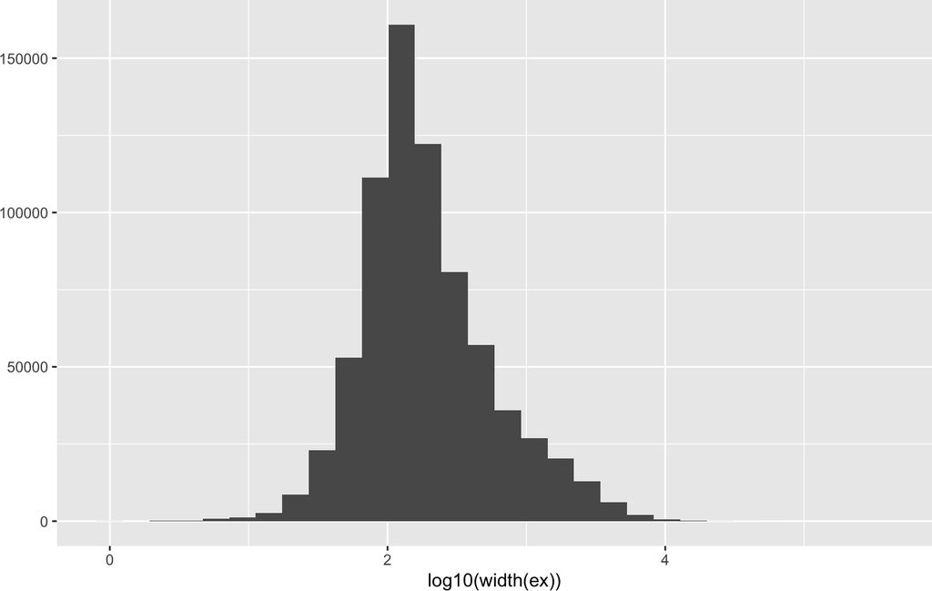

   ```r
   library(ggplot2)
   qplot(log10(width(ex)))
   ```

   ```r
   ex[ which.max(width(ex)) ]
   ```

   ```
   ## GRanges object with 1 range and 1 metadata column:
   ##       seqnames              ranges strand |   exon_id
   ##          <Rle>           <IRanges>  <Rle> | <integer>
   ##   [1]     chrX 113616300-113963599      - |    662308
   ##   -------
   ##   seqinfo: 711 sequences (1 circular) from hg38 genome
   ```

3. Extract all genes, and then keep only the ‘standard’ chromosomes 1:22, X, Y, and M. Use `table()` of `seqnames()` to determine how many genes are on each chromosome. Also do this in a dplyr way; note that the `seqnames(gn)` need to be coerced with `as.factor()`.

   ```r
   gn <- genes(txdb)
   ```

   ```
   ##   1690 genes were dropped because they have exons located on both strands
   ##   of the same reference sequence or on more than one reference sequence,
   ##   so cannot be represented by a single genomic range.
   ##   Use 'single.strand.genes.only=FALSE' to get all the genes in a
   ##   GRangesList object, or use suppressMessages() to suppress this message.
   ```

   ```r
   length(gn)
   ```

   ```
   ## [1] 31074
   ```

   ```r
   std <- paste0("chr", c(1:22, "X", "Y", "M"))
   seqlevels(gn, pruning.mode = "coarse") <- std
   length(gn)
   ```

   ```
   ## [1] 30970
   ```

   ```r
   seqlevels(gn)
   ```

   ```
   ##  [1] "chr1"  "chr2"  "chr3"  "chr4"  "chr5"  "chr6"  "chr7"  "chr8"  "chr9"
   ## [10] "chr10" "chr11" "chr12" "chr13" "chr14" "chr15" "chr16" "chr17" "chr18"
   ## [19] "chr19" "chr20" "chr21" "chr22" "chrX"  "chrY"  "chrM"
   ```

   ```r
   table( seqnames(gn) )
   ```

   ```
   ##
   ##  chr1  chr2  chr3  chr4  chr5  chr6  chr7  chr8  chr9 chr10 chr11 chr12 chr13
   ##  3104  2152  1745  1304  1501  1435  1497  1122  1245  1254  1803  1541   720
   ## chr14 chr15 chr16 chr17 chr18 chr19 chr20 chr21 chr22  chrX  chrY  chrM
   ##  1010  1054  1259  1572   555  1762   879   444   673  1205   134     0
   ```

   ```r
   tibble(chr = as.factor(seqnames(gn))) |>
       group_by(chr) |>
       summarize(n = n())
   ```

   ```
   ## # A tibble: 24 × 2
   ##    chr       n
   ##    <fct> <int>
   ##  1 chr1   3104
   ##  2 chr2   2152
   ##  3 chr3   1745
   ##  4 chr4   1304
   ##  5 chr5   1501
   ##  6 chr6   1435
   ##  7 chr7   1497
   ##  8 chr8   1122
   ##  9 chr9   1245
   ## 10 chr10  1254
   ## # ℹ 14 more rows
   ```

4. `exonsBy()` groups exons by gene or transcript; extract exons grouped by gene. (Challenging!) can you identify genes with exons on different chromosomes? Are there any of these genes on the standard chromosomes?

   ```r
   exByGn <- exonsBy(txdb, "gene")
   ##
   trans <- lengths(unique(seqnames(exByGn)))
   table( trans )
   ```

   ```
   ## trans
   ##     1     2     3     4     5     6     7     8     9    10    12    13    16
   ## 31074  1269   131    40    28    38    77    75     2    17     2     1     2
   ##    31    33    38    39    41    43
   ##     1     3     1     1     1     1
   ```

   ```r
   seqnames( exByGn[ trans > 1 ] )
   ```

   ```
   ## RleList of length 1690
   ## $`10000`
   ## factor-Rle of length 89 with 2 runs
   ##   Lengths:                  63                  26
   ##   Values : chr1                chr1_KI270763v1_alt
   ## Levels(711): chr1 chr2 chr3 ... chrX_MU273396v1_alt chrX_MU273397v1_alt
   ##
   ## $`10003`
   ## factor-Rle of length 76 with 2 runs
   ##   Lengths:                   38                   38
   ##   Values : chr11                chr11_KZ559110v1_alt
   ## Levels(711): chr1 chr2 chr3 ... chrX_MU273396v1_alt chrX_MU273397v1_alt
   ##
   ## $`100033819`
   ## factor-Rle of length 2 with 2 runs
   ##   Lengths:                    1                    1
   ##   Values : chr11                chr11_ML143358v1_fix
   ## Levels(711): chr1 chr2 chr3 ... chrX_MU273396v1_alt chrX_MU273397v1_alt
   ##
   ## $`100037417`
   ## factor-Rle of length 6 with 2 runs
   ##   Lengths:                    3                    3
   ##   Values : chr22                chr22_KI270879v1_alt
   ## Levels(711): chr1 chr2 chr3 ... chrX_MU273396v1_alt chrX_MU273397v1_alt
   ##
   ## $`100049076`
   ## factor-Rle of length 18 with 2 runs
   ##   Lengths:                   4                  14
   ##   Values : chr5                chr5_KI270897v1_alt
   ## Levels(711): chr1 chr2 chr3 ... chrX_MU273396v1_alt chrX_MU273397v1_alt
   ##
   ## ...
   ## <1685 more elements>
   ```

   ```r
   ##
   std <- paste0("chr", c(1:22, "X", "Y", "M"))
   unames <- unique(seqnames(exByGn[ trans > 1 ]))
   transstd <- all(unames %in% std)
   unames[transstd]
   ```

   ```
   ## FactorList of length 27
   ## [["100128260"]] chrX chrY
   ## [["100359394"]] chrX chrY
   ## [["100500894"]] chrX chrY
   ## [["101928092"]] chrX chrY
   ## [["102464837"]] chrX chrY
   ## [["105373105"]] chrX chrY
   ## [["1438"]] chrX chrY
   ## [["207063"]] chrX chrY
   ## [["28227"]] chrX chrY
   ## [["286530"]] chrX chrY
   ## ...
   ## <17 more elements>
   ```

5. The previous exercise indicated that gene `"22947"` has exons on both chromosomes 4 and 10. Find out more about this gene using the org.Hs.eg.db package and by searching for the gene symbol on the NCBI web site.

   ```r
   egid <- "22947"
   AnnotationDbi::select(
       org.Hs.eg.db, egid, c("SYMBOL", "GENENAME"), "ENTREZID"
   )
   ```

   ```
   ##   ENTREZID SYMBOL                              GENENAME
   ## 1    22947 DUX4L1 double homeobox 4 like 1 (pseudogene)
   ```

   ```r
   url <- paste0("https://www.ncbi.nlm.nih.gov/gene/", egid)
   browseURL(url)
   ```

6. Note that the `TxDb.*` packages also support `keytypes()`, `columns()`, and `select()` for mapping between exon, cds, transcript, and gene identifiers.

**Exercise 5**: `BSgenome.*` packages

1. Install (if necessary) and load the [BSgenome.Hsapiens.UCSC.hg38](http://bioconductor.org/packages/Bsgenome.Hsapiens.UCSC.hg38) package, containing the entire sequence of the hg38 build of *Homo sapiens*. Check out it’s contents, and create a simple alias.

   ```r
   library(BSgenome.Hsapiens.UCSC.hg38)
   BSgenome.Hsapiens.UCSC.hg38
   ```

   ```
   ## | BSgenome object for Human
   ## | - organism: Homo sapiens
   ## | - provider: UCSC
   ## | - genome: hg38
   ## | - release date: 2023/01/31
   ## | - 711 sequence(s):
   ## |     chr1                    chr2                    chr3
   ## |     chr4                    chr5                    chr6
   ## |     chr7                    chr8                    chr9
   ## |     chr10                   chr11                   chr12
   ## |     chr13                   chr14                   chr15
   ## |     ...                     ...                     ...
   ## |     chr19_KV575256v1_alt    chr19_KV575257v1_alt    chr19_KV575258v1_alt
   ## |     chr19_KV575259v1_alt    chr19_KV575260v1_alt    chr19_MU273387v1_alt
   ## |     chr22_KN196485v1_alt    chr22_KN196486v1_alt    chr22_KQ458387v1_alt
   ## |     chr22_KQ458388v1_alt    chr22_KQ759761v1_alt    chrX_KV766199v1_alt
   ## |     chrX_MU273395v1_alt     chrX_MU273396v1_alt     chrX_MU273397v1_alt
   ## | Tips: call 'seqnames()' on the object to get all the sequence names, call
   ## | 'seqinfo()' to get the full sequence info, use the '$' or '[[' operator to
   ## | access a given sequence, see '?BSgenome' for more information.
   ```

   ```r
   hg38 <- BSgenome.Hsapiens.UCSC.hg38
   ```

2. Genomic sequence can be retrieved by chromosome, e.g., `hg38[["chr1"]]`, or by genomic range, e.g., `getSeq(hg38, GRanges("chr1:1000000-2000000"))`. Retrieve your favorite chunk(s) of DNA and calculate GC content.

   ```r
   dna <- getSeq(hg38, GRanges("chr1:1000000-2000000"))
   letterFrequency(dna, "GC", as.prob=TRUE)
   ```

   ```
   ##            G|C
   ## [1,] 0.5728534
   ```

3. Use the `org.*`, `TxDb.*`, and `BSgenome.*` packages to retrieve the BRCA1 exon DNA sequence.

   ```r
   brca1_egid <- mapIds(org.Hs.eg.db, "BRCA1", "ENTREZID", "SYMBOL")
   brca1_exons <- exonsBy(txdb, "gene")[[brca1_egid]]
   getSeq(hg38, brca1_exons)
   ```

   ```
   ## DNAStringSet object of length 97:
   ##      width seq
   ##  [1]  1508 CAATTGGGCAGATGTGTGAGGCACCTGTGGTGA...CACTGCAAATAAACTTGGTAGCAAACACTTCCA
   ##  [2]  1501 CAATTGGGCAGATGTGTGAGGCACCTGTGGTGA...CTGTTAACACTGCAAATAAACTTGGTAGCAAAC
   ##  [3]   998 CAATTGGGCAGATGTGTGAGGCACCTGTGGTGA...TGAGACTGTGGCTCAAAAAAAAAAAAAAAAAAA
   ##  [4]   822 CAATTGGGCAGATGTGTGAGGCACCTGTGGTGA...TGGCCAACATGGTGAAACCCCATCTCTACTAAA
   ##  [5]   717 CAATTGGGCAGATGTGTGAGGCACCTGTGGTGA...AAAAGGAAACTTGAAACCTGGGCATGGTGGCTC
   ##  ...   ... ...
   ## [93]   126 ACAGATAAATTAAAACTGCGACTGCGCGGCGTG...CTGCGCTCAGGAGGCCTTCACCCTCTGCTCTGG
   ## [94]   174 TTAGCGGTAGCCCCTTGGTTTCCGTGGCAACGG...CTGCGCTCAGGAGGCCTTCACCCTCTGCTCTGG
   ## [95]   175 CTTAGCGGTAGCCCCTTGGTTTCCGTGGCAACG...CTGCGCTCAGGAGGCCTTCACCCTCTGCTCTGG
   ## [96]   207 GTACCTTGATTTCGTATTCTGAGAGGCTGCTGC...CTGCGCTCAGGAGGCCTTCACCCTCTGCTCTGG
   ## [97]   120 AAAGCGTGGGAATTACAGATAAATTAAAACTGT...GGCCGCGTTGGGGTGAGACCCTCACTTCATCCG
   ```

**Exercise 6**

This exercise uses annotation resources to go from a gene symbol ‘BRCA1’ through to the genomic coordinates of each transcript associated with the gene, and finally to the DNA sequences of the transcripts. This can be achieved using an `EnsDb` package along with a BSgenome package, or with a combination of `TxDb`, Homo.sapiens and BSgenome packages. We will focus here on the former approach.

0. Use AnnotationHub to discover and retrieve a current Ensembl annotation (‘EnsDb’) for *Homo sapiens*.
1. Use the `cdsBy()` function to retrieve the genomic coordinates of all coding sequences for the gene ‘BRCA1’ from the EnsDb.Hsapiens.v86 package. To retrieve only data for the specified gene, submit either a `GenenameFilter` or a filter formula/expression to the function’s `filter` parameter. This avoids to extract the coding region for all genes, which takes a long time.
2. Visualize the transcripts in genomic coordinates using the Gviz package to construct a `GeneRegionTrack`, and plotting it using `plotTracks()`.
3. Use the Bsgenome.Hsapiens.UCSC.hg38 package and `extractTranscriptSeqs()` function to extract the DNA sequence of each transcript.

**Solution**

Retrieve the coding sequences grouped by transcript for the gene of interest and verify that each coding sequence is a multiple of 3.

```r
library(EnsDb.Hsapiens.v86)
edb <- EnsDb.Hsapiens.v86

brca1cds <- cdsBy(edb, by = "tx", filter = ~ genename == "BRCA1")

class(brca1cds)
```

```
## [1] "CompressedGRangesList"
## attr(,"package")
## [1] "GenomicRanges"
```

```r
length(brca1cds)
```

```
## [1] 29
```

```r
brca1cds[[1]]                           # exons in cds
```

```
## GRanges object with 21 ranges and 3 metadata columns:
##        seqnames            ranges strand |   gene_name         exon_id
##           <Rle>         <IRanges>  <Rle> | <character>     <character>
##    [1]       17 43124017-43124096      - |       BRCA1 ENSE00003559512
##    [2]       17 43115726-43115779      - |       BRCA1 ENSE00003510592
##    [3]       17 43106456-43106533      - |       BRCA1 ENSE00003541068
##    [4]       17 43104868-43104956      - |       BRCA1 ENSE00003531836
##    [5]       17 43104122-43104261      - |       BRCA1 ENSE00003513709
##    ...      ...               ...    ... .         ...             ...
##   [17]       17 43057052-43057135      - |       BRCA1 ENSE00003458468
##   [18]       17 43051063-43051117      - |       BRCA1 ENSE00003477922
##   [19]       17 43049121-43049194      - |       BRCA1 ENSE00003628864
##   [20]       17 43047643-43047703      - |       BRCA1 ENSE00003687053
##   [21]       17 43045678-43045802      - |       BRCA1 ENSE00001814242
##        exon_rank
##        <integer>
##    [1]         2
##    [2]         3
##    [3]         4
##    [4]         5
##    [5]         6
##    ...       ...
##   [17]        18
##   [18]        19
##   [19]        20
##   [20]        21
##   [21]        22
##   -------
##   seqinfo: 1 sequence from GRCh38 genome
```

```r
cdswidth <- width(brca1cds)             # width of each exon
all((sum(cdswidth) %% 3) == 0)          # sum within cds, modulus 3
```

```
## [1] FALSE
```

The CDS for some transcripts is not of the expected length, how come? Get the transcript ID of the first transcript that does have a CDS of the wrong size and look this transcript up in the Ensembl genome browser (http://www.ensembl.org).

```r
tx_cds_fail <- names(brca1cds)[(sum(cdswidth) %% 3) != 0]

length(tx_cds_fail)
```

```
## [1] 10
```

```r
tx_cds_fail[1]
```

```
## [1] "ENST00000412061"
```

In the description of the transcript it says *CDS 5’ incomplete*. Thus, in addition to known protein coding transcripts, Ensembl provides annotations for transcripts known to be targeted for nonsense mediated mRNA decay or that have incomplete CDS. Such transcripts would however not be listed in e.g. the TxDb.Hsapiens.UCSC.hg38.knownGene package.

Next we visualize the BRCA1 transcripts using Gviz (this package has an excellent vignette, `vignette("Gviz")`)

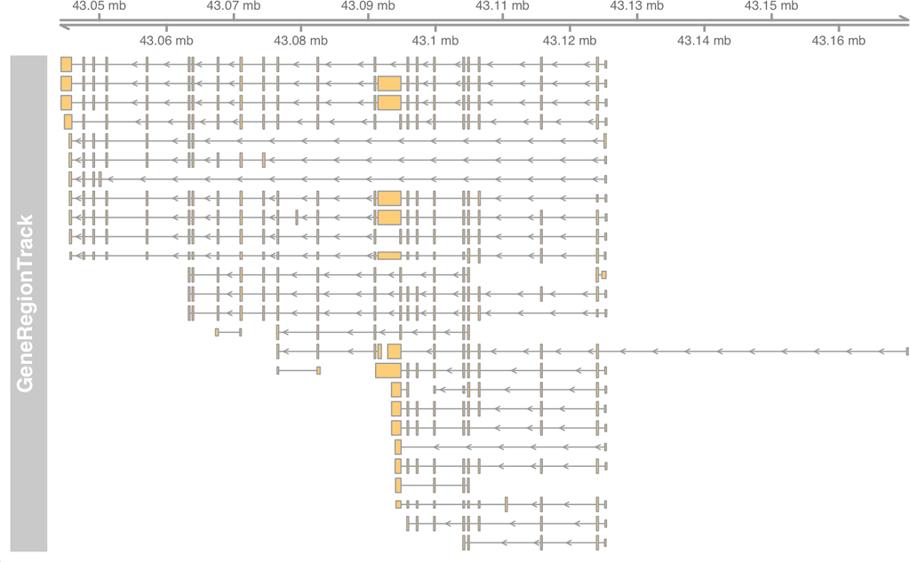

```r
library(Gviz)

## Use the function from the ensembldb package to extract the data in the
## format suitable for Gviz
grt <- getGeneRegionTrackForGviz(edb, filter = ~genename == "BRCA1")
plotTracks(list(GenomeAxisTrack(), GeneRegionTrack(grt)))
```

Extract the coding sequences of each transcript. `EnsDb` databases provide annotations from Ensembl and use hence Ensembl style chromosome names (such as “Y”) while the `BSgenome` package is based on UCSC annotations that use a naming style that prepends a “chr” to each chromosome name (e.g. “chrY”). Change thus the `seqlevelsStyle` from the default UCSC chromosome naming to Ensembl naming style.

```r
library(BSgenome.Hsapiens.UCSC.hg38)
genome <- BSgenome.Hsapiens.UCSC.hg38

## Change the seqlevelsStyle from UCSC to Ensembl
seqlevelsStyle(genome) <- "Ensembl"
tx_seq <- extractTranscriptSeqs(genome, brca1cds)
tx_seq
```

```
## DNAStringSet object of length 29:
##      width seq                                              names
##  [1]  2166 ATGGATTTATCTGCTCTTCGCGT...GATCCCCCACAGCCACTACTGA ENST00000352993
##  [2]  4200 ATGGATTTATCTGCTCTTCGCGT...ACAAATTTCCAAGTATAGTTAA ENST00000354071
##  [3]  5592 ATGGATTTATCTGCTCTTCGCGT...GATCCCCCACAGCCACTACTGA ENST00000357654
##  [4]  1312 GTTTGGATTCTGCAAAAAAGGCT...GTGAAGAGATAAAGAAAAAAAA ENST00000412061
##  [5]   192 ATGGATTTATCTGCTCTTCGCGT...GCCTTCACAGTGTCCTTTATGA ENST00000461221
##  ...   ... ...
## [25]  1065 ATGCACAGTTGCTCTGGGAGTCT...GATCCCCCACAGCCACTACTGA ENST00000591534
## [26]   291 ATGAGTGACAGCAAGAAAACCTG...GATCCCCCACAGCCACTACTGA ENST00000591849
## [27]    71 ATGGATTTATCTGCTCTTCGCGT...CTATGCAGAAAATCTTAGAGTG ENST00000618469
## [28]  2395 ATGGATTTATCTGCTCTTCGCGT...TTGGGACATGAAGTTAACCACA ENST00000634433
## [29]  5592 ATGGATTTATCTGCTCTTCGCGT...GATCCCCCACAGCCACTACTGA LRG_292t1
```

We can also inspect the CDS sequence for the transcripts with incomplete CDS. Many of them do not start with a start codon hence indicating that the CDS is incomplete on their 5’ end.

```r
tx_seq[tx_cds_fail]
```

```
## DNAStringSet object of length 10:
##      width seq                                              names
##  [1]  1312 GTTTGGATTCTGCAAAAAAGGCT...GTGAAGAGATAAAGAAAAAAAA ENST00000412061
##  [2]   958 TTCAGCTTGACACAGGTTTGGAG...TTCACTCCAAATCAGTAGAGAG ENST00000473961
##  [3]   667 ATGGATTTATCTGCTCTTCGCGT...AGTTTGGATTCTGCAAAAAAGG ENST00000476777
##  [4]  1867 ATGGATTTATCTGCTCTTCGCGT...GATAGTTGTTCTAGCAGTGAAG ENST00000477152
##  [5]  1870 ATGGATTTATCTGCTCTTCGCGT...CAGTCTATTAAAGAAAGAAAAA ENST00000478531
##  [6]  1495 GAGCTATTGAAAATCATTTGTGC...CAGTCTATTAAAGAAAGAAAAA ENST00000484087
##  [7]   800 GAGCTATTGAAAATCATTTGTGC...ATAAAGAACCAGGAGTGGAAAG ENST00000487825
##  [8]   296 ATGGATTTATCTGCTCTTCGCGT...TAAAAGATGAAGTTTCTATCAT ENST00000489037
##  [9]    71 ATGGATTTATCTGCTCTTCGCGT...CTATGCAGAAAATCTTAGAGTG ENST00000618469
## [10]  2395 ATGGATTTATCTGCTCTTCGCGT...TTGGGACATGAAGTTAACCACA ENST00000634433
```

Intron coordinates can be identified by first calculating the range of the genome (from the start of the first exon to the end of the last exon) covered by each transcript, and then taking the (algebraic) set difference between this and the genomic coordinates covered by each exon

```r
introns <- psetdiff(unlist(range(brca1cds)), brca1cds)
```

Retrieve the intronic sequences with `getSeq()` (these are *not* assembled, the way that `extractTranscriptSeqs()` assembles exon sequences into mature transcripts); note that introns start and end with the appropriate acceptor and donor site sequences. Unfortunately, UCSC and Ensembl do also use different names for the genome assembly. Change the genome name for the `introns` object to matche the one from the `genome` object.

```r
unique(genome(genome))
```

```
## [1] "hg38"
```

```r
genome(introns)
```

```
##       17
## "GRCh38"
```

```r
## Change the genome name on introns to match the one from the
## BSgenome package
genome(introns) <- c(`17` = unique(genome(genome)))

seq <- getSeq(genome, introns)
names(seq)
```

```
##  [1] "ENST00000352993" "ENST00000354071" "ENST00000357654" "ENST00000412061"
##  [5] "ENST00000461221" "ENST00000461574" "ENST00000461798" "ENST00000468300"
##  [9] "ENST00000470026" "ENST00000471181" "ENST00000473961" "ENST00000476777"
## [13] "ENST00000477152" "ENST00000478531" "ENST00000484087" "ENST00000487825"
## [17] "ENST00000489037" "ENST00000491747" "ENST00000492859" "ENST00000493795"
## [21] "ENST00000493919" "ENST00000494123" "ENST00000497488" "ENST00000586385"
## [25] "ENST00000591534" "ENST00000591849" "ENST00000618469" "ENST00000634433"
## [29] "LRG_292t1"
```

```r
seq[["ENST00000352993"]]                     # 20 introns
```

```
## DNAStringSet object of length 20:
##      width seq
##  [1]  1840 GTAAGGTGCCTGCATGTACCTGTGCTATATGGG...ACACTAATCTCTGCTTGTGTTCTCTGTCTCCAG
##  [2]  1417 GTAAGTATTGGGTGCCCTGTCAGAGAGGGAGGA...ACTTTGAATGCTCTTTCCTTCCTGGGGATCCAG
##  [3]  1868 GTAAGAGCCTGGGAGAACCCCAGAGTTCCAGCA...TGCAGTGATTTTACATCTAAATGTCCATTTTAG
##  [4]  5934 GTAAAGCTCCCTCCCTCAAGTTGACAAAAATCT...CCCCTGTCCCTCTCTCTTCCTCTCTTCTTCCAG
##  [5]  6197 GTAAGTACTTGATGTTACAAACTAACCAGAGAT...TTATCCTGATGGGTTGTGTTTGGTTTCTTTCAG
##  ...   ... ...
## [16]  4241 GTAAAACCATTTGTTTTCTTCTTCTTCTTCTTC...AATTGCTTGACTGTTCTTTACCATACTGTTTAG
## [17]   606 GTAAGTGTTGAATATCCCAAGAATGACACTCAA...TGCAAACATAATGTTTTCCCTTGTATTTTACAG
## [18]  1499 GTATATAATTTGGTAATGATGCTAGGTTGGAAG...GCTGAGTGTGTTTCTCAAACAATTTAATTTCAG
## [19]  9192 GTAAGTTTGAATGTGTTATGTGGCTCCATTATT...TTAAATTGTTCTTTCTTTCTTTATAATTTATAG
## [20]  8237 GTAAGTCAGCACAAGAGTGTATTAATTTGGGAT...TTATTTTCTTTTTCTCCCCCCCTACCCTGCTAG
```

**Exercise 7**

Internet access required for this exercise

Here we use rtracklayer to retrieve estrogen receptor binding sites identified across cell lines in the ENCODE project. We focus on binding sites in the vicinity of a particularly interesting region.

1. Define our region of interest by creating a `GRanges` instance with appropriate genomic coordinates. Our region corresponds to 10Mb up- and down-stream of a particular gene.
2. Create a session for the UCSC genome browser
3. Query the UCSC genome browser for ENCODE estrogen receptor ERalpha<sub>a</sub> transcription marks; identifying the appropriate track, table, and transcription factor requires biological knowledge and detective work.
4. Visualize the location of the binding sites and their scores; annotate the mid-point of the region of interest.

**Solution**

Define the region of interest

```r
library(GenomicRanges)
roi <- GRanges("chr10", IRanges(92106877, 112106876, names="ENSG00000099194"))
```

Create a session

```r
library(rtracklayer)
session <- browserSession()
```

Query the UCSC for a particular track, table, and transcription factor, in our region of interest

```r
trackName <- "wgEncodeRegTfbsClusteredV2"
tableName <- "wgEncodeRegTfbsClusteredV2"
trFactor <- "ERalpha_a"
ucscTable <- getTable(ucscTableQuery(session, track=trackName,
    range=roi, table=tableName, name=trFactor))
```

Visualize the result

```r
plot(score ~ chromStart, ucscTable, pch="+")
abline(v=start(roi) + (end(roi) - start(roi) + 1) / 2, col="blue")
```

# 3 AnnotationHub

AnnotationHub is a data base of large-scale whole-genome resources, e.g., regulatory elements from the Roadmap Epigenomics project, Ensembl GTF and FASTA files for model and other organisms, and the NHLBI grasp2db data base of GWAS results. There are many interesting ways in which these resources can be used. Examples include

AnnotationHub makes extensive use of internet resources and so we will not pursue it in this course extensively; see the vignettes that come with the pacakge, for instance [*AnnotationHub* HOW-TOs](http://bioconductor.org/packages/devel/bioc/vignettes/AnnotationHub/inst/doc/AnnotationHub-HOWTO.html). Also see Wednesday’s annotation lecture and additional materials for more information on AnnotationHub and ExperimentHub.

Create a session

```r
library(AnnotationHub)
hub = AnnotationHub()
hub
```

```
## AnnotationHub with 70130 records
## # snapshotDate(): 2023-04-24
## # $dataprovider: Ensembl, BroadInstitute, UCSC, ftp://ftp.ncbi.nlm.nih.gov/g...
## # $species: Homo sapiens, Mus musculus, Drosophila melanogaster, Bos taurus,...
## # $rdataclass: GRanges, TwoBitFile, BigWigFile, EnsDb, Rle, OrgDb, ChainFile...
## # additional mcols(): taxonomyid, genome, description,
## #   coordinate_1_based, maintainer, rdatadateadded, preparerclass, tags,
## #   rdatapath, sourceurl, sourcetype
## # retrieve records with, e.g., 'object[["AH5012"]]'
##
##              title
##   AH5012   | Chromosome Band
##   AH5013   | STS Markers
##   AH5014   | FISH Clones
##   AH5015   | Recomb Rate
##   AH5016   | ENCODE Pilot
##   ...        ...
##   AH113536 | org.Alternaria_alternata.eg.sqlite
##   AH113537 | org.Alternaria_tenuis.eg.sqlite
##   AH113538 | org.Torula_alternata.eg.sqlite
##   AH113539 | org.Psilocybe_cubensis.eg.sqlite
##   AH113540 | org.Stropharia_cubensis.eg.sqlite
```

Finding what you need in the hubs requires a well formed query or subset call against the metadata columns of the searchable database. What types of metadata columns are available?

```r
names(mcols(hub))
```

```
##  [1] "title"              "dataprovider"       "species"
##  [4] "taxonomyid"         "genome"             "description"
##  [7] "coordinate_1_based" "maintainer"         "rdatadateadded"
## [10] "preparerclass"      "tags"               "rdataclass"
## [13] "rdatapath"          "sourceurl"          "sourcetype"
```

You can see what values are in each metadata columns

```r
head(unique(hub$dataprovider))
```

```
## [1] "UCSC"        "Ensembl"     "RefNet"      "Inparanoid8" "NHLBI"
## [6] "ChEA"
```

```r
head(unique(hub$rdataclass))
```

```
## [1] "GRanges"          "data.frame"       "Inparanoid8Db"    "TwoBitFile"
## [5] "ChainFile"        "SQLiteConnection"
```

There are two ways to search for data subset and query. Query is recommended as subset involves an exact match search while query is less strict.

```r
query(hub, c("granges","homo sapiens","ensembl"))
```

```
## AnnotationHub with 121 records
## # snapshotDate(): 2023-04-24
## # $dataprovider: Ensembl, UCSC, TargetScan,miRTarBase,USCS,ENSEMBL
## # $species: Homo sapiens, homo sapiens
## # $rdataclass: GRanges
## # additional mcols(): taxonomyid, genome, description,
## #   coordinate_1_based, maintainer, rdatadateadded, preparerclass, tags,
## #   rdatapath, sourceurl, sourcetype
## # retrieve records with, e.g., 'object[["AH5046"]]'
##
##              title
##   AH5046   | Ensembl Genes
##   AH5160   | Ensembl Genes
##   AH5311   | Ensembl Genes
##   AH5434   | Ensembl Genes
##   AH5435   | Ensembl EST Genes
##   ...        ...
##   AH110100 | Homo_sapiens.GRCh38.108.gtf
##   AH110866 | Homo_sapiens.GRCh38.109.abinitio.gtf
##   AH110867 | Homo_sapiens.GRCh38.109.chr.gtf
##   AH110868 | Homo_sapiens.GRCh38.109.chr_patch_hapl_scaff.gtf
##   AH110869 | Homo_sapiens.GRCh38.109.gtf
```

You can look at the full metadata for a resource without downloading by using a single square bracket. A double bracket will download the resource and cache it locally.

```r
hub["AH110100"]
```

```
## AnnotationHub with 1 record
## # snapshotDate(): 2023-04-24
## # names(): AH110100
## # $dataprovider: Ensembl
## # $species: homo sapiens
## # $rdataclass: GRanges
## # $rdatadateadded: 2022-10-30
## # $title: Homo_sapiens.GRCh38.108.gtf
## # $description: Gene Annotation for homo sapiens
## # $taxonomyid: 9606
## # $genome: GRCh38.p13
## # $sourcetype: GTF
## # $sourceurl: ftp://ftp.ensembl.org/pub/release-108/gtf/homo_sapiens/Homo_sa...
## # $sourcesize: 54107597
## # $tags: c("GTF", "ensembl", "Gene", "Transcript", "Annotation")
## # retrieve record with 'object[["AH110100"]]'
```

# 4 Annotating variants

*Bioconductor* provides facilities for reading VCF files. These work very well with the annotation resources described above, so for instance it is straight-forward to identify variants in coding or other regions of interest.

To develop a sense of the capabilities available, work through the VariantAnnotation vignette ‘Introduction to Variant Annotation’, and the VariantFiltering vignette.

# 5 End matter

## 5.2 Acknowledgements

Research reported in this tutorial was supported by the National Human Genome Research Institute and the National Cancer Institute of the National Institutes of Health under award numbers U24HG004059 (Bioconductor), U24HG010263 (AnVIL) and U24CA180996 (ITCR).